# Week 4 Assignment

LinJie Yang

## Introduction

Using devices such as Jawbone Up, Nike FuelBand, and Fitbit it is now possible to collect a large amount of data about personal activity relatively inexpensively. These type of devices are part of the quantified self movement – a group of enthusiasts who take measurements about themselves regularly to improve their health, to find patterns in their behavior, or because they are tech geeks. One thing that people regularly do is quantify how much of a particular activity they do, but they rarely quantify how well they do it. In this project, your goal will be to use data from accelerometers on the belt, forearm, arm, and dumbell of 6 participants. They were asked to perform barbell lifts correctly and incorrectly in 5 different ways. More information is available from the website here: [http://web.archive.org/web/20161224072740/http:/groupware.les.inf.puc-rio.br/har] (see the section on the Weight Lifting Exercise Dataset).

## Loading the dataset

```r
library(caret)
```

```r
library(rpart)
library(rpart.plot)
library(RColorBrewer)
library(RGtk2)
```

[output not shown]

[output not shown]

[output not shown]

[output not shown]

```r
library(rattle)
library(randomForest)
library(gbm)
```

```r
train_url<-"http://d396qusza40orc.cloudfront.net/predmachlearn/pml-training.csv"
test_url<-"http://d396qusza40orc.cloudfront.net/predmachlearn/pml-testing.csv"

init_org_training_data<-read.csv(url(train_url))
init_org_testing_data<-read.csv(url(test_url))
```

```r
dim(init_org_training_data)
```

```
## [1] 19622   160
```

##2. Data Cleaning## **Removing Variables which have nearly zero variance**

```r
non_zero_var<-nearZeroVar(init_org_training_data)
org_training_data<-init_org_training_data[,-non_zero_var]
org_testing_data<-init_org_testing_data[,-non_zero_var]
```

**Removing Variables which have NAs,Our threshhold is 95 percent**

```r
na_val_col<-sapply(org_training_data,function(x)mean(is.na(x)))>0.95
org_training_data<-org_training_data[,na_val_col==FALSE]
org_testing_data<-org_testing_data[,na_val_col==FALSE]
```

```r
org_training_data<-org_training_data[,8:59]
org_testing_data<-org_testing_data[,8:59]
```

##Data Partitioning## We will seggregate our org_training_data into 2 different parts,one is the training set(60 percent of the total data) and test set(40 percent of the total data)

```r
inTrain<-createDataPartition(org_training_data$classe,p=0.6,list=FALSE)
training<-org_training_data[inTrain,]
testing<-org_training_data[-inTrain,]
```

##Decision Tree Model##

```r
DT_modfit<-train(classe~.,data=training,method='rpart')
```

Prediction in terms of the Decision Tree Model

```r
DT_prediction<-predict(DT_modfit,testing)
confusionMatrix(DT_prediction,testing$classe)
```

```
## Confusion Matrix and Statistics
##
##           Reference
## Prediction    A    B    C    D    E
##          A 2015  604  621  554  328
##          B   54  541   49  261  323
##          C  119  173  600  197  193
##          D   44  199   98  274  185
##          E    0    1    0    0  413
##
## Overall Statistics
##
##                Accuracy : 0.4898
##                  95% CI : (0.4787, 0.5009)
##     No Information Rate : 0.2845
##     P-Value [Acc > NIR] : < 2.2e-16
##
##                   Kappa : 0.3334
##
##  Mcnemar's Test P-Value : < 2.2e-16
##
## Statistics by Class:
##
##                      Class: A Class: B Class: C Class: D Class: E
## Sensitivity            0.9028  0.35639  0.43860  0.21306  0.28641
## Specificity            0.6247  0.89143  0.89472  0.91982  0.99984
## Pos Pred Value         0.4888  0.44055  0.46802  0.34250  0.99758
## Neg Pred Value         0.9417  0.85237  0.88300  0.85637  0.86154
## Prevalence             0.2845  0.19347  0.17436  0.16391  0.18379
## Detection Rate         0.2568  0.06895  0.07647  0.03492  0.05264
## Detection Prevalence   0.5254  0.15651  0.16340  0.10196  0.05277
## Balanced Accuracy      0.7637  0.62391  0.66666  0.56644  0.64313
```

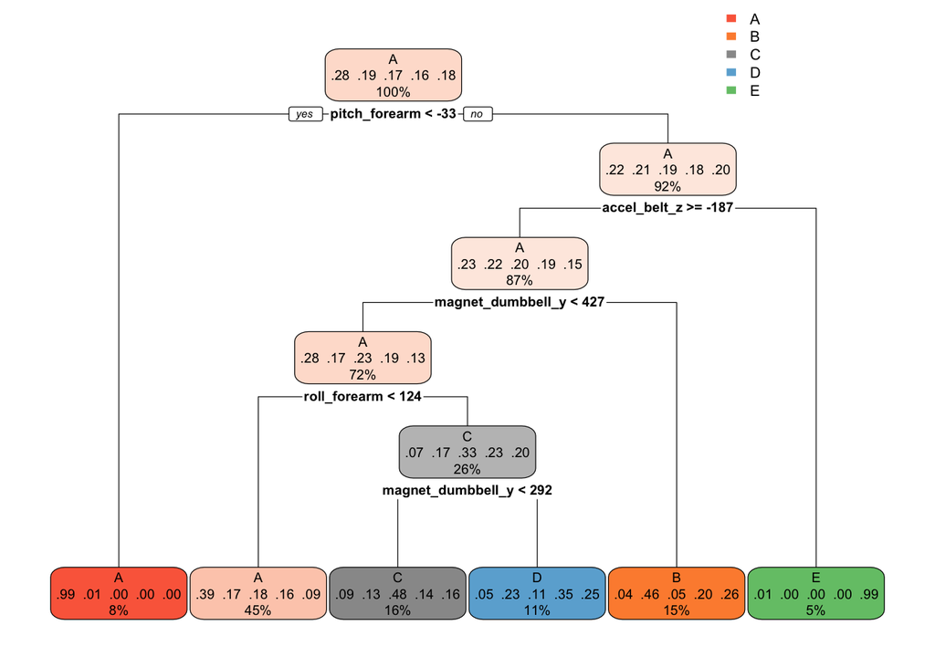

```r
rpart.plot(DT_modfit$finalModel,roundint=FALSE)
```

The prediction accuracy is 50 percent which not upto the desired level.

##Random Forest Model##

```r
RF_modfit<-train(classe~.,data=training,method='rf',ntree=100)
```

Prediction in terms of Random Forest Model

```r
RF_prediction<-predict(RF_modfit,testing)
RF_pred_conf<-confusionMatrix(RF_prediction,testing$classe)
RF_pred_conf
```

```
## Confusion Matrix and Statistics
##
##           Reference
## Prediction    A    B    C    D    E
##          A 2228   15    0    0    0
##          B    2 1499   19    1    0
##          C    1    3 1342   15    5
##          D    0    0    7 1269    3
##          E    1    1    0    1 1434
##
## Overall Statistics
##
##                Accuracy : 0.9906
##                  95% CI : (0.9882, 0.9926)
##     No Information Rate : 0.2845
##     P-Value [Acc > NIR] : < 2.2e-16
##
##                   Kappa : 0.9881
##
##  Mcnemar's Test P-Value : NA
##
## Statistics by Class:
##
##                      Class: A Class: B Class: C Class: D Class: E
## Sensitivity            0.9982   0.9875   0.9810   0.9868   0.9945
## Specificity            0.9973   0.9965   0.9963   0.9985   0.9995
## Pos Pred Value         0.9933   0.9855   0.9824   0.9922   0.9979
## Neg Pred Value         0.9993   0.9970   0.9960   0.9974   0.9988
## Prevalence             0.2845   0.1935   0.1744   0.1639   0.1838
## Detection Rate         0.2840   0.1911   0.1710   0.1617   0.1828
## Detection Prevalence   0.2859   0.1939   0.1741   0.1630   0.1832
## Balanced Accuracy      0.9978   0.9920   0.9886   0.9926   0.9970
```

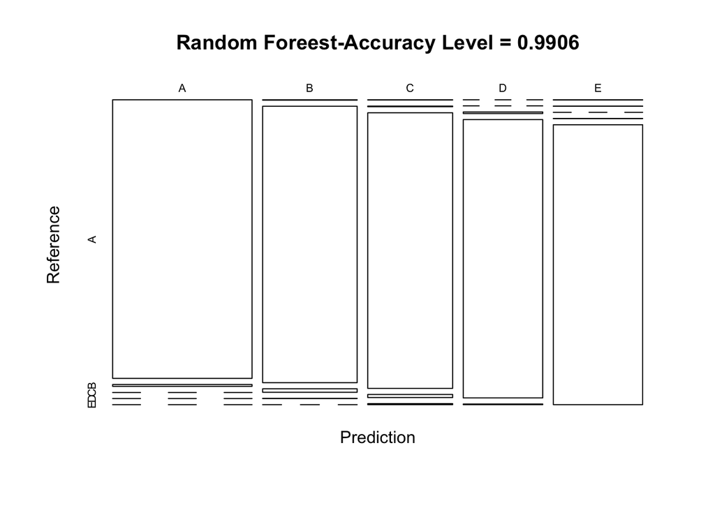

```r
plot(RF_pred_conf$table,col=RF_pred_conf$byClass,main=paste("Random Foreest-Accuracy Level =",round(RF_pred_conf$overall['Accuracy'],4)))
```

According to the Confusion Matrix, we can see that the prediction accuracy of Randorm Forest model is 99 percent.

##Gradient Boosting Model##

```r
GBM_modfit<-train(classe~.,data=training,method='gbm',verbose=FALSE)
GBM_modfit$finalModel
```

```
## A gradient boosted model with multinomial loss function.
## 150 iterations were performed.
## There were 51 predictors of which 51 had non-zero influence.
```

```r
GBM_prediction<-predict(GBM_modfit,testing)
GBM_pred_conf<-confusionMatrix(GBM_prediction,testing$classe)
GBM_pred_conf
```

```
## Confusion Matrix and Statistics
##
##           Reference
## Prediction    A    B    C    D    E
##          A 2198   37    0    2    3
##          B   19 1431   44   11    8
##          C   13   44 1301   43   11
##          D    2    3   19 1213   19
##          E    0    3    4   17 1401
##
## Overall Statistics
##
##                Accuracy : 0.9615
##                  95% CI : (0.957, 0.9657)
##     No Information Rate : 0.2845
##     P-Value [Acc > NIR] : < 2.2e-16
##
##                   Kappa : 0.9513
##
##  Mcnemar's Test P-Value : 9.993e-06
##
## Statistics by Class:
##
##                      Class: A Class: B Class: C Class: D Class: E
## Sensitivity            0.9848   0.9427   0.9510   0.9432   0.9716
## Specificity            0.9925   0.9870   0.9829   0.9934   0.9963
## Pos Pred Value         0.9813   0.9458   0.9214   0.9658   0.9832
## Neg Pred Value         0.9939   0.9863   0.9896   0.9889   0.9936
## Prevalence             0.2845   0.1935   0.1744   0.1639   0.1838
## Detection Rate         0.2801   0.1824   0.1658   0.1546   0.1786
## Detection Prevalence   0.2855   0.1928   0.1800   0.1601   0.1816
## Balanced Accuracy      0.9886   0.9649   0.9669   0.9683   0.9839
```

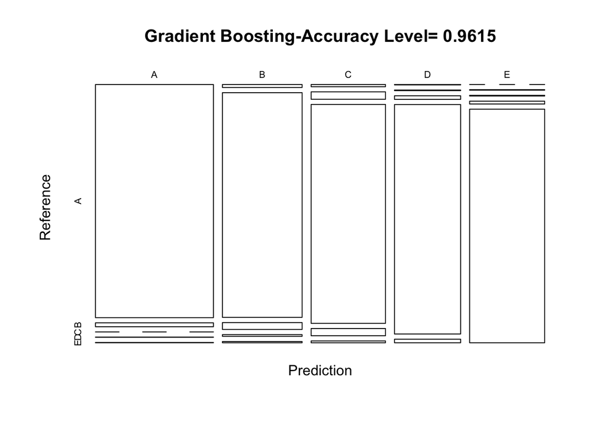

```r
plot(GBM_pred_conf$table,col=GBM_pred_conf$byClass,main=paste("Gradient Boosting-Accuracy Level=",round(GBM_pred_conf$overall['Accuracy'],4)))
```

##We need to see how each model has predicted the validation dataset across the classifications.## We do not consider Decision Tree model as it didn’t reach the satisfactory prediction accuracy level. Only Random Forest and Gradient Boosting methods are being compared.

```r
RF_pred_conf$overall
```

```
##       Accuracy          Kappa  AccuracyLower  AccuracyUpper   AccuracyNull
##      0.9905684      0.9880679      0.9881738      0.9925871      0.2844762
## AccuracyPValue  McnemarPValue
##      0.0000000            NaN
```

```r
GBM_pred_conf$overall
```

```
##       Accuracy          Kappa  AccuracyLower  AccuracyUpper   AccuracyNull
##   9.615090e-01   9.513068e-01   9.570136e-01   9.656573e-01   2.844762e-01
## AccuracyPValue  McnemarPValue
##   0.000000e+00   9.992603e-06
```

##Conclusion## After checking the Overall Statistics data, the Random Forest model has defintely more accuracy than GBM. Hence we will be selecting Random Forest model for final predicvtion from org_testing_data.

##Final Prediction-Applying selected moedl on the Test Data##

```r
Final_RF_prediction<-predict(RF_modfit,org_testing_data)
Final_RF_prediction
```

```
##  [1] B A B A A E D B A A B C B A E E A B B B
## Levels: A B C D E
```